# Segunda semana

JMV

May 4, 2015

Ejemplito de la clase Calcula la desviaciones estandar de un monton de medias de normales con sigma 1

debera tender a s/sqrt(n)

```r
nosim<-1000
n<-10
sd(apply(matrix(rnorm(nosim*n),nosim),1,mean))
```

```
## [1] 0.3063226
```

y esto se podria hacer para cualquier distribucion

por ejemplo, con monedas, que tienen una varianza de 0.25 asi que se deberia aproximar a 1/2sqrt(n)

```r
nosim<-1000
n<-10
sd(apply(matrix(sample(0:1,nosim*n,replace=T),nosim),1,mean))
```

```
## [1] 0.1598382
```

Uso de la bunomial

pbinom()

Calcular la probabilidad de tener en 8 hijos 7 nignaas o mas (que el mamon de la clase lo ha puesto con el culo)

se pone el 6 por que es hasta 6 y despues el lower.tail=F para que calcule el X>x

```r
pbinom(6,8,.5,lower.tail = F)
```

```
## [1] 0.03515625
```

## Ejemplos de uso del teorema del limite central

Simular una normal estandar usando dados de seis caras (con dos cojones)

los dados tienen mu =3.5

la varianza es 2.92

la media tendra un error de medida de 1.71/sqrt(n)

si tiramos n dados, hacemos la media, restamos 3.5 y dividimos por el error deberia tender a una normal

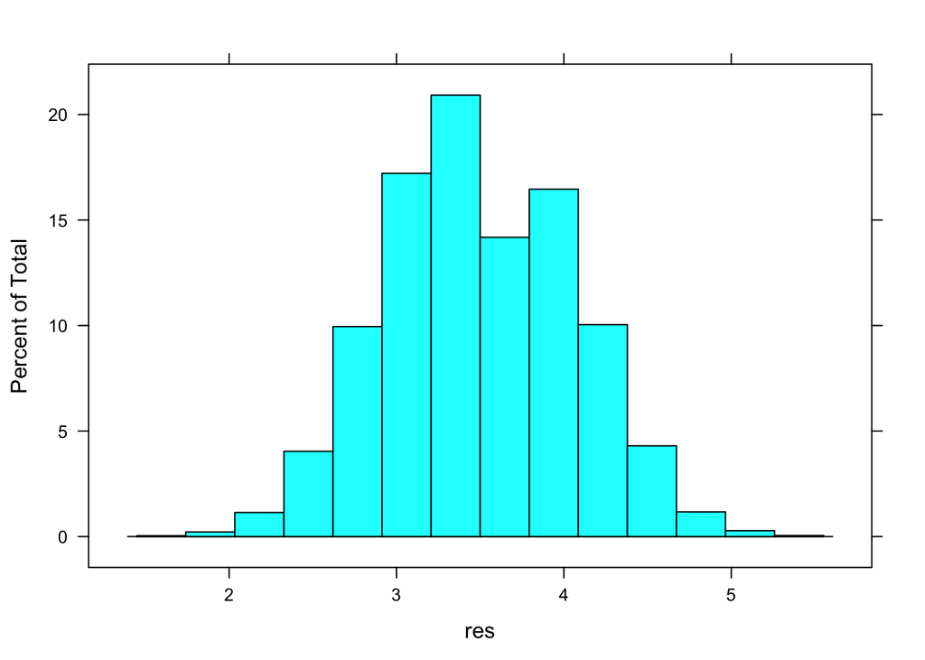

```r
library(lattice)
nosim<-10000
n<-10
res<-apply(matrix(sample(1:6,nosim*n,replace=T),nosim),1,mean)
histogram(res)
```

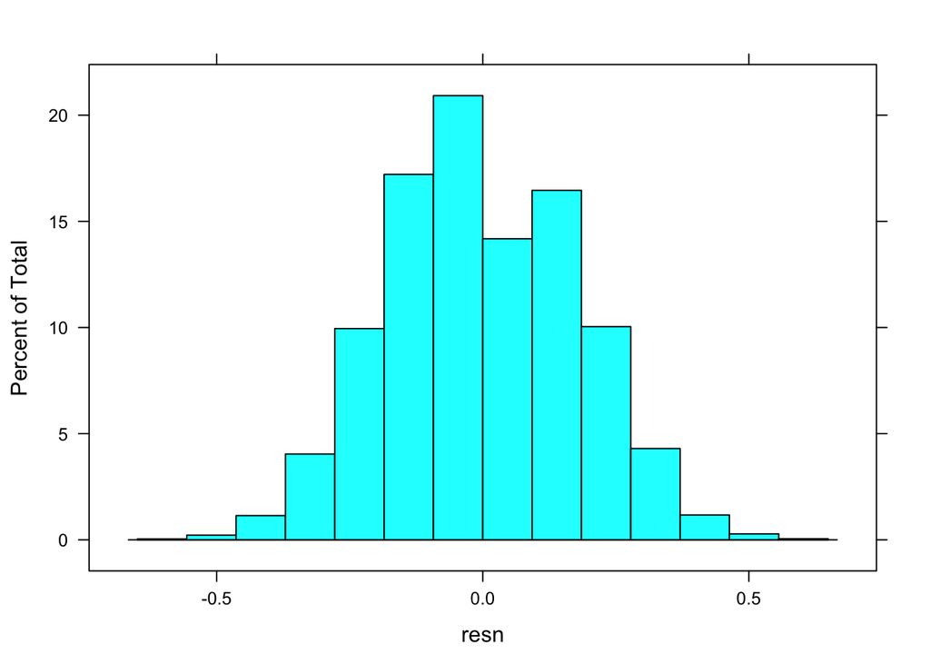

```r
resn<-(res-3.5)/sqrt(n)
histogram(resn)
```

Podemos meterle mas cagna y hacer 100 lanzamientos por vez, y se va aproximando a una normal

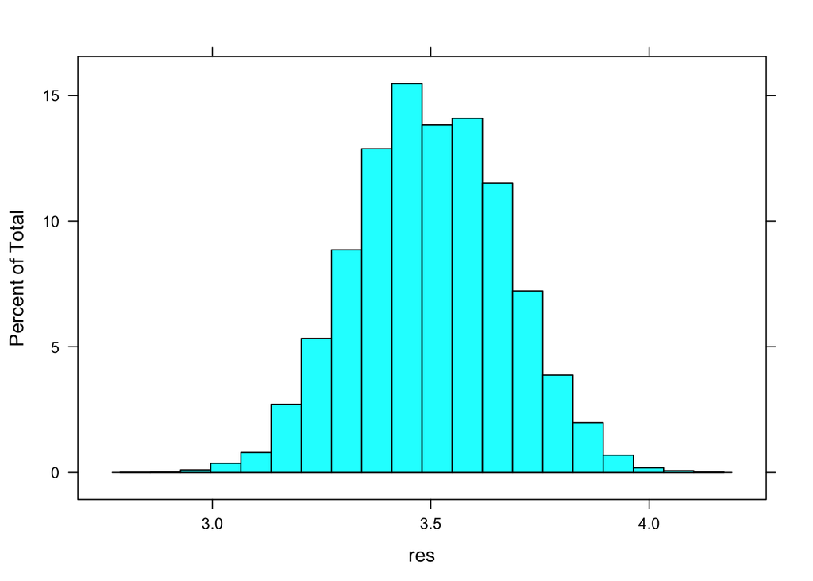

```r
library(lattice)
nosim<-10000
n<-100
res<-apply(matrix(sample(1:6,nosim*n,replace=T),nosim),1,mean)
histogram(res,nint=20)
```

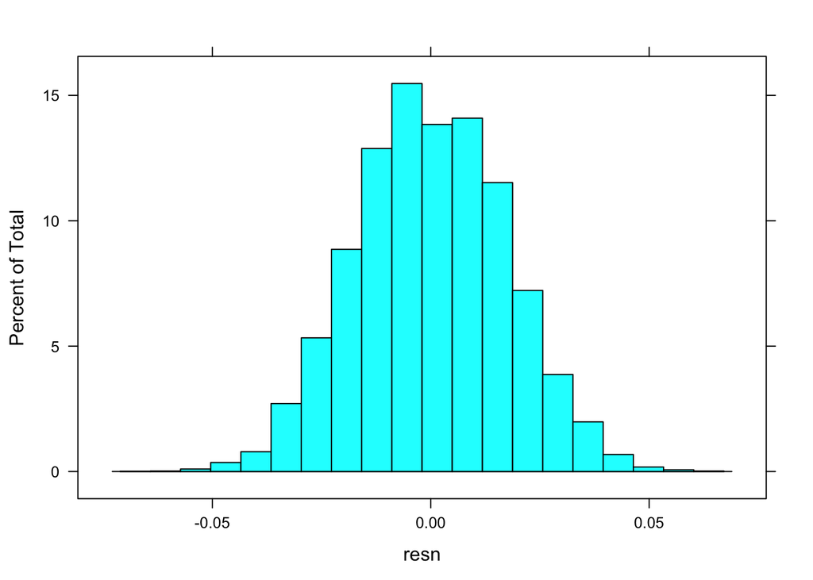

```r
resn<-(res-3.5)/sqrt(n)
histogram(resn,nint=20)
```

Un ejemplito para hacer multiples tests vamos a usar una simulacion cambiando los valores de p metidos en pvals estimamos p a partir de la media y calculamos a ver cuantas veces se falla en que el valor calculado con su margen de confianza deja dentro fuera el p verdadero

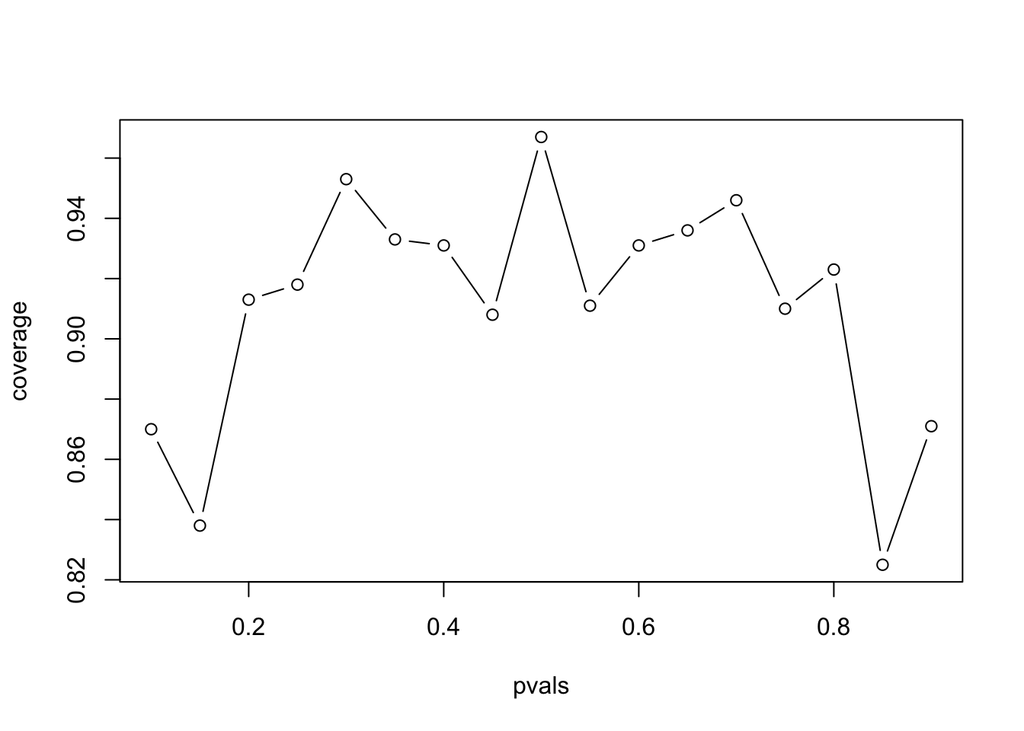

```r
n<-20
pvals<- seq(0.1,0.9, by =0.05)
nosim<-1000
coverage<-sapply(pvals,function(p){
    phats<-rbinom(nosim,prob=p,size=n)/n
    ll<-phats-qnorm(0.975)*sqrt(phats*(1-phats)/n)
    ul<-phats+qnorm(0.975)*sqrt(phats*(1-phats)/n)
    mean(ll<p & ul >p)
})
plot (pvals,coverage,type="b")
```

Se ve que la estimacion es bastante mejor para p en torno a 0,5 y en general parece que n es demasiado peque??o

Fix bruto: subimos n y se ve que mejora bastante

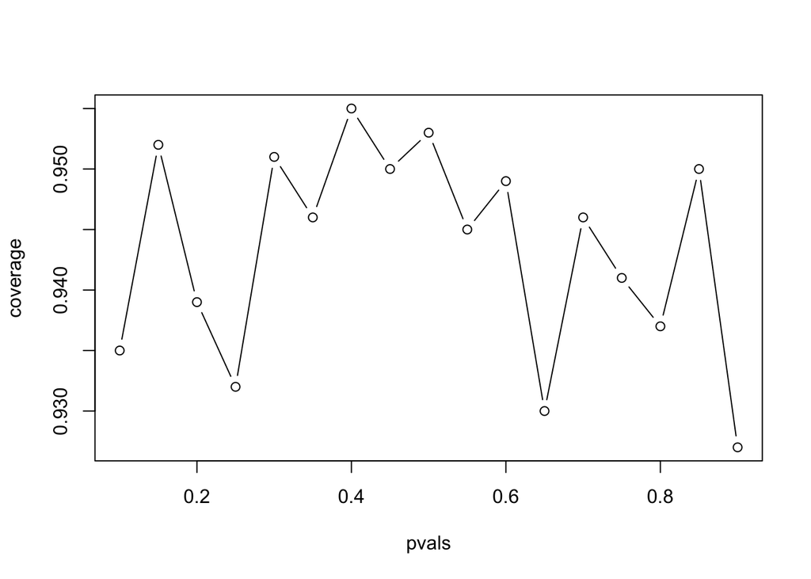

```r
n<-200
pvals<- seq(0.1,0.9, by =0.05)
nosim<-1000
coverage<-sapply(pvals,function(p){
    phats<-rbinom(nosim,prob=p,size=n)/n
    ll<-phats-qnorm(0.975)*sqrt(phats*(1-phats)/n)
    ul<-phats+qnorm(0.975)*sqrt(phats*(1-phats)/n)
    mean(ll<p & ul >p)
})
plot (pvals,coverage,type="b")
```

Fix mas elegante sumamos 2 al total de monedas sacadas y 4 al n total, esto se denomina intervalo de Agresti /Coull

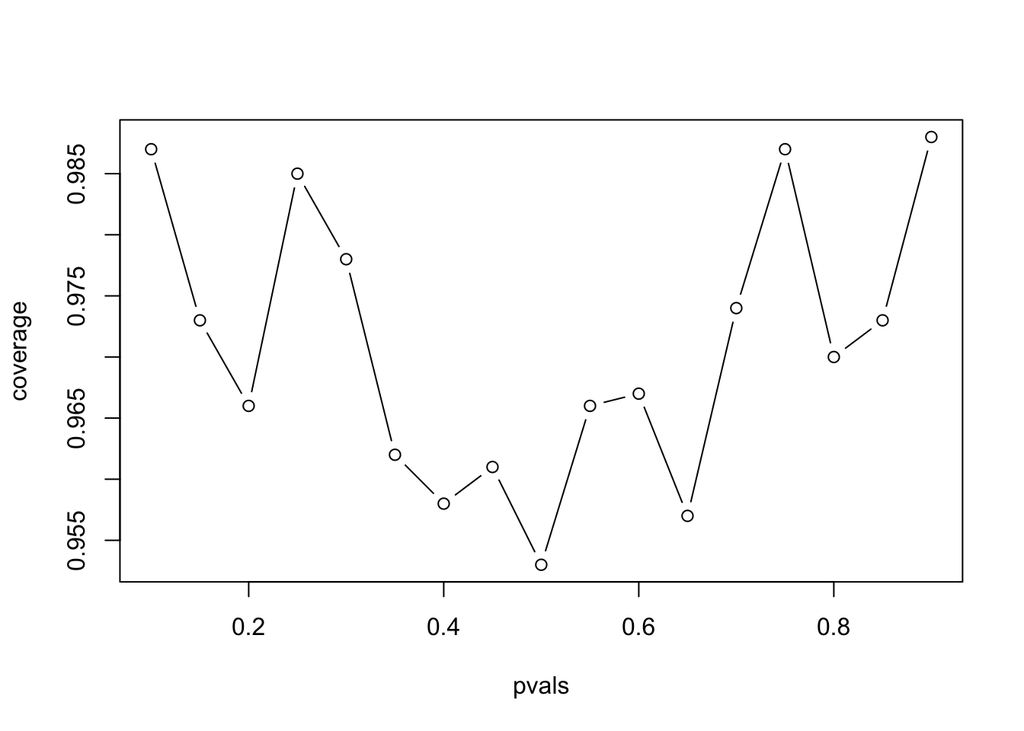

```r
n<-20
pvals<- seq(0.1,0.9, by =0.05)
nosim<-1000
coverage<-sapply(pvals,function(p){
    phats<-(rbinom(nosim,prob=p,size=n)+2)/(n+4)
    ll<-phats-qnorm(0.975)*sqrt(phats*(1-phats)/n)
    ul<-phats+qnorm(0.975)*sqrt(phats*(1-phats)/n)
    mean(ll<p & ul >p)
})
plot (pvals,coverage,type="b")
```

Vamos a hacer lo mismo simulando una distro de poisson

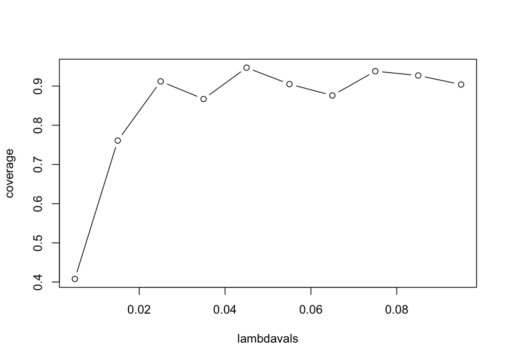

```r
lambdavals<- seq(0.005,0.1, by =0.01)
nosim<-1000
t<-100
coverage<-sapply(lambdavals,function(lambda){
    lhats<-rpois(nosim,lambda = lambda*t)/t
    ll<-lhats-qnorm(0.975)*sqrt(lhats/t)
    ul<-lhats+qnorm(0.975)*sqrt(lhats/t)
    mean(ll<lambda & ul >lambda)
})
plot (lambdavals,coverage,type="b")
```

Posiblemente t sea demasiado peque??o (en realidad el problema es el producto lambra + t) por que hay pocos eventos

con t =1000 mejora mucho

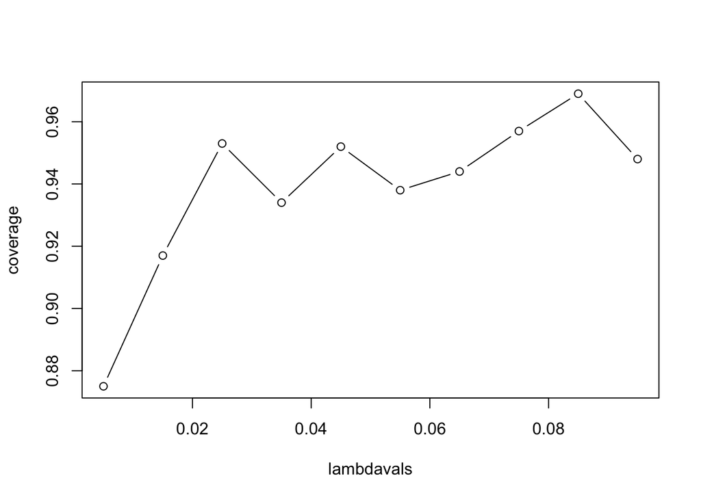

```r
lambdavals<- seq(0.005,0.1, by =0.01)
nosim<-1000
t<-1000
coverage<-sapply(lambdavals,function(lambda){
    lhats<-rpois(nosim,lambda = lambda*t)/t
    ll<-lhats-qnorm(0.975)*sqrt(lhats/t)
    ul<-lhats+qnorm(0.975)*sqrt(lhats/t)
    mean(ll<lambda & ul >lambda)
})
plot (lambdavals,coverage,type="b")
```